# 2. Parametric Models and Sensitivity Analysis

Team 1 (``Destroyers"): Jesus Vazquez, Leo Li, Ying Zhang, Tian Zhao

5/5/2021

This R Markdown file contains the workflow for conducting the analysis using logistic regression and ridge logistic regression.

We start by loading the package that we built, called `ridgeLR`:

```r
knitr::opts_chunk$set(warning = FALSE, message = FALSE)
dirdata <- "C:/Users/brave/OneDrive/Desktop/Bios 735"
setwd(dirdata)
install.packages("ridgeLR_0.0.1.tar.gz", repos = NULL)
library(ridgeLR)
```

```r
library(pROC)
library(ggplot2)
library(ROCR)
```

First, the logistic regression is used to conduct the analysis and produce the predicted probabilities for the test set.

```r
# fitting the model
setwd(dirdata)
dat <- read.csv(paste0("train_cc.csv"))
y <- as.matrix(dat$target)
X <- as.matrix(dat[,2:(dim(dat)[2]-1)])
X = scale(X, center = T, scale = T)
logistic.beta.cc = logistic_regression(y, X)

#produce the predicted probabilities for the test set
test <- read.csv("test.csv")
X.test <- as.matrix(test[,2:(dim(test)[2]-1)])
X.test = scale(X.test, center = T, scale = T)
LP <- X.test %*% logistic.beta.cc
prob <- 1/(1+exp(-LP))
logistic.cc <- data.frame(y.test = test$target, prob = prob)
```

Second, the ridge logistic regression is used to conduct the analysis and produce the predicted probabilities for the test set.

```r
# fitting the model
setwd(dirdata)
dat <- read.csv(paste0("train_cc.csv"))
y <- as.matrix(dat$target)
X <- as.matrix(dat[,2:(dim(dat)[2]-1)])
X = scale(X, center = T, scale = T)
lambda <- cv_ridge_logistic_regression(y, X, (0:20)*0.01, 5)
```

```
## 123451234512345123451234512345123451234512345123451234512345123451234512345123451234512345123451234512345
```

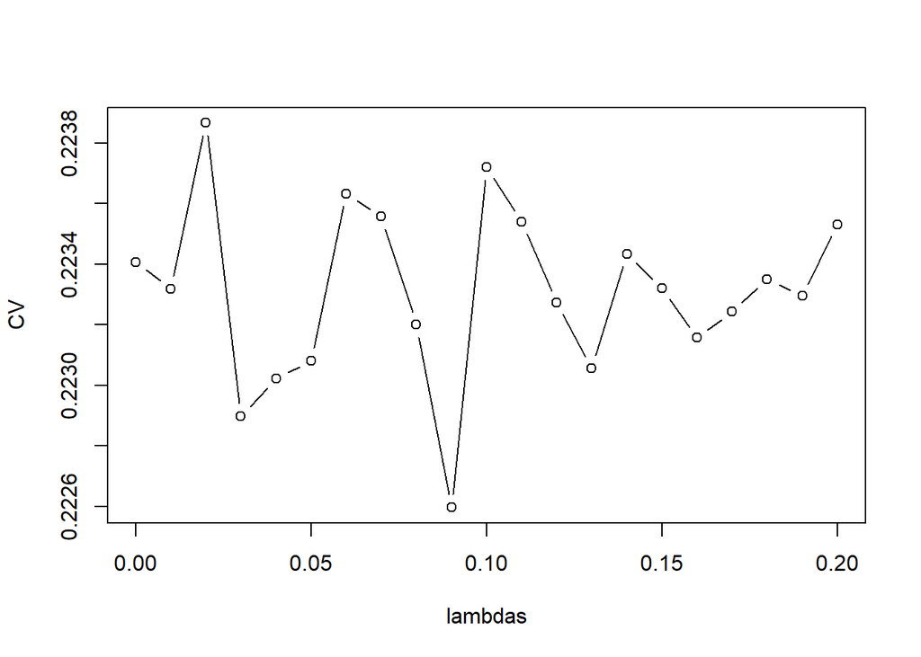

```
## [1] "tunning parameter = 0.09; CV score = 0.222597313095859"
```

```r
ridge.logistic.beta.cc =  ridge_logistic_regression_beta(y, X, lambda)

#produce the predicted probabilities for the test set
test <- read.csv("test.csv")
X.test <- as.matrix(test[,2:(dim(test)[2]-1)])
X.test = scale(X.test, center = T, scale = T)
LP <- X.test %*% ridge.logistic.beta.cc
prob <- 1/(1+exp(-LP))
ridge.logistic.cc <- data.frame(y.test = test$target, prob = prob)
```

```r
labels = test$target
predictions_LR = logistic.cc[,2]
predictions_RLR = ridge.logistic.cc[,2]
aucs_LR = auc(labels,predictions_LR)
aucs_RLR = auc(labels,predictions_RLR)

# generate the preds dataset for ROC curve
preds_LR = prediction(predictions_LR, labels)
preds_RLR = prediction(predictions_RLR, labels)
perf_RLR = performance(preds_RLR,"tpr","fpr")
perf_LR = performance(preds_LR,"tpr","fpr")
```

Third, FCS multiple imputation is used to handle the missing data, and the logistic regression is used to conduct the analysis and produce the predicted probabilities for the test set.

```r
# fitting the model
setwd(dirdata)
beta.cum <- rep(0, 52)
for (i in 1:5){
  mi1 <- read.csv(paste0("train_mi_", i, ".csv"))
  y <- as.matrix(mi1$target)
  X <- as.matrix(mi1[,2:(dim(mi1)[2]-1)])
  X = scale(X, center = T, scale = T)
  beta = logistic_regression(y, X)
  beta.cum <- beta.cum+beta
}
logistic.beta.mi <- beta.cum/5

#produce the predicted probabilities for the test set
test <- read.csv("test.csv")
X.test <- as.matrix(test[,2:(dim(test)[2]-1)])
X.test = scale(X.test, center = T, scale = T)
LP <- X.test %*% logistic.beta.mi
prob <- 1/(1+exp(-LP))
logistic.mi <- data.frame(y.test = test$target, prob = prob)
```

Finally, FCS multiple imputation is used to handle the missing data, and the ridge logistic regression is used to conduct the analysis and produce the predicted probabilities for the test set.

```r
# fitting the model
setwd(dirdata)
beta.cum <- rep(0, 52)
for (i in 1:5){
  mi1 <- read.csv(paste0("train_mi_", i, ".csv"))
  y <- as.matrix(mi1$target)
  X <- as.matrix(mi1[,2:(dim(mi1)[2]-1)])
  X = scale(X, center = T, scale = T)
  lambda <- cv_ridge_logistic_regression(y, X, (0:20)*0.01, 5)
  beta =  ridge_logistic_regression_beta(y, X, lambda)
  beta.cum <- beta.cum+beta
}
```

```
## 123451234512345123451234512345123451234512345123451234512345123451234512345123451234512345123451234512345
```

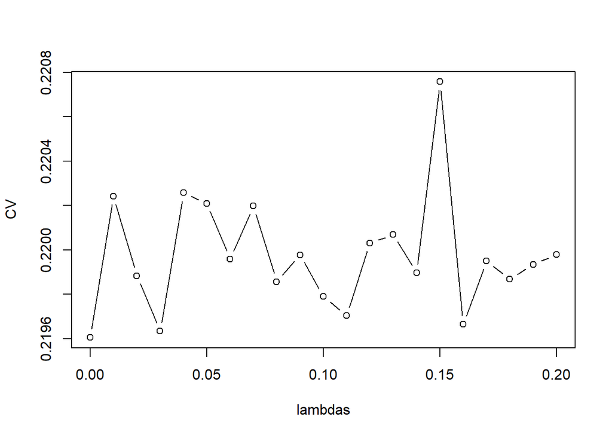

```
## [1] "tunning parameter = 0; CV score = 0.219605075569335"
## 123451234512345123451234512345123451234512345123451234512345123451234512345123451234512345123451234512345
```

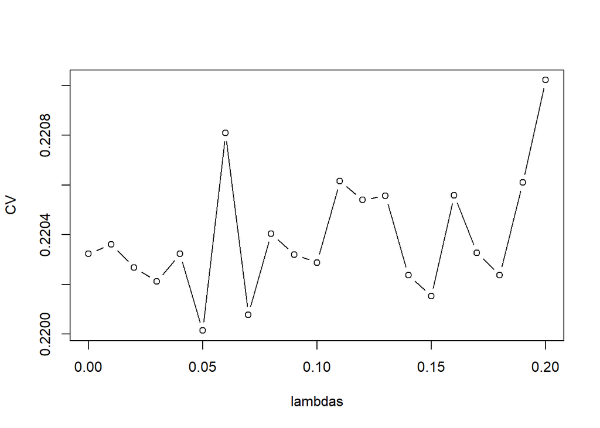

```
## [1] "tunning parameter = 0.05; CV score = 0.220014273797163"
## 123451234512345123451234512345123451234512345123451234512345123451234512345123451234512345123451234512345
```

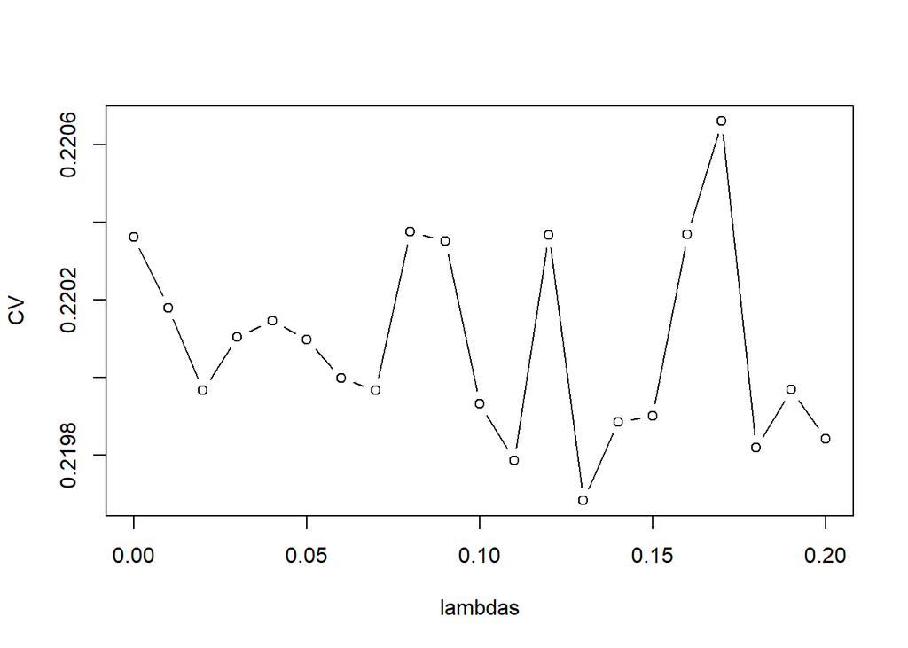

```
## [1] "tunning parameter = 0.13; CV score = 0.219683206529301"
## 123451234512345123451234512345123451234512345123451234512345123451234512345123451234512345123451234512345
```

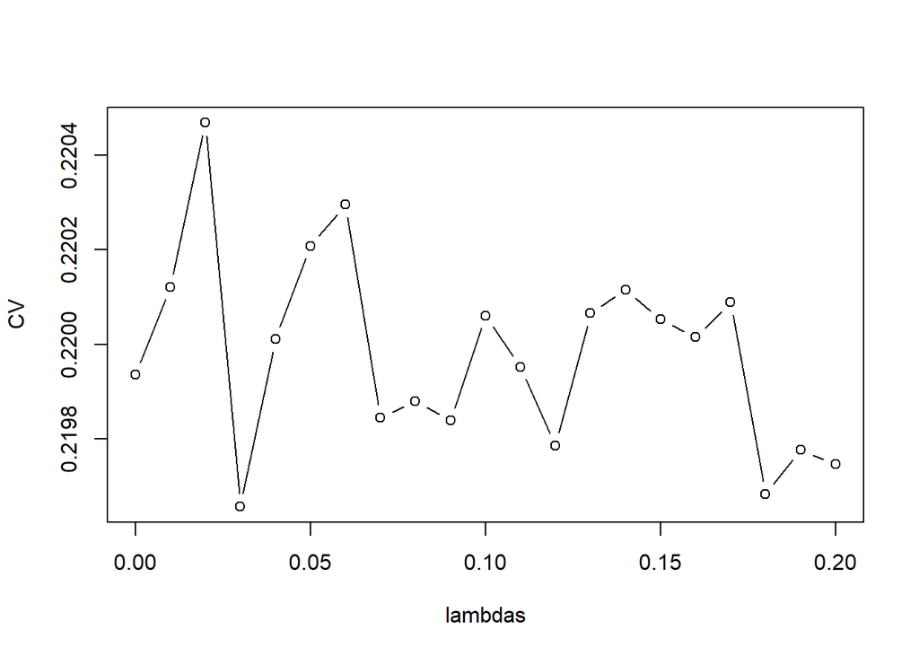

```
## [1] "tunning parameter = 0.03; CV score = 0.219656313853445"
## 123451234512345123451234512345123451234512345123451234512345123451234512345123451234512345123451234512345
```

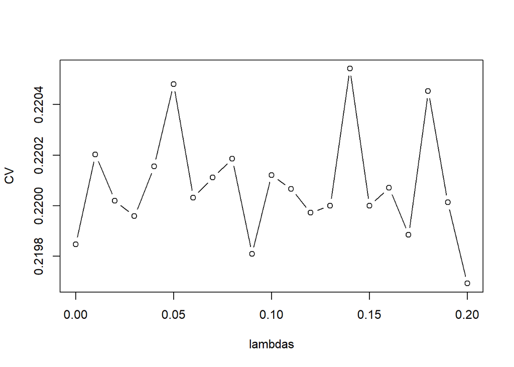

```
## [1] "tunning parameter = 0.2; CV score = 0.219693224266428"
```

```r
ridge.logistic.beta.mi <- beta.cum/5

#produce the predicted probabilities for the test set
test <- read.csv("test.csv")
X.test <- as.matrix(test[,2:(dim(test)[2]-1)])
X.test = scale(X.test, center = T, scale = T)
LP <- X.test %*% ridge.logistic.beta.mi
prob <- 1/(1+exp(-LP))
ridge.logistic.mi <- data.frame(y.test = test$target, prob = prob)
```

After we have trained all the models and get our coefficients and predicted probabilities, we can move on to get our roc curves.

[figure not shown]

```r
LRMI_pred <- logistic.mi
RLRMI_pred <- ridge.logistic.mi
aucs_LRMI = auc(LRMI_pred$y.test,LRMI_pred$prob)
aucs_RLRMI = auc(RLRMI_pred$y.test,RLRMI_pred$prob)
# generate the preds dataset for ROC curve
preds_LRMI = prediction(LRMI_pred$prob, LRMI_pred$y.test)
preds_RLRMI = prediction(RLRMI_pred$prob, RLRMI_pred$y.test)
perf_LRMI = performance(preds_LRMI,"tpr","fpr")
perf_RLRMI = performance(preds_RLRMI,"tpr","fpr")

plot(perf_LR,col=2,main="ROC curves by Logistic regression and Ridge logistic regression")
plot(perf_RLR,col=2,add = TRUE)
plot(perf_LRMI,col=4,add = TRUE)
plot(perf_RLRMI,col=4,add = TRUE)
abline(0,1)
legend("bottomright",c("colorful: LR&RLR","imputed LR&RLR"),fill=c("red","blue"))
```

Computing all aucs.

```r
AUCs = as.data.frame(rbind(aucs_LR,aucs_RLR,aucs_LRMI,aucs_RLRMI))
AUCs
```

```
##                   V1
## aucs_LR    0.7630005
## aucs_RLR   0.7629833
## aucs_LRMI  0.7609486
## aucs_RLRMI 0.7609546
```

The scaled differences plot of the estimated coefficient by logistic regression using complete cases and imputed cases.

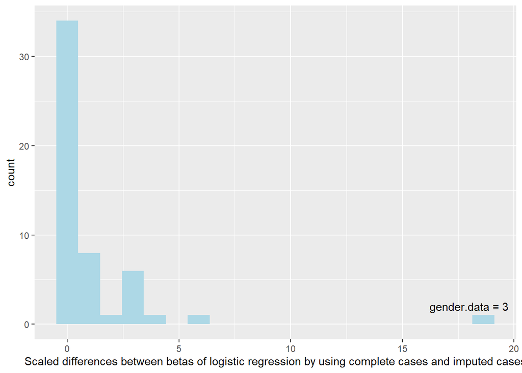

```r
library(ggplot2)
# read estimated veta of different

beta_MI_LR <- logistic.beta.cc
beta_LR <- logistic.beta.mi
coln = colnames(test)[2:53]
dat1 = as.data.frame(coln)

# diff_beta = LR - imputed LR
dat1$diff_beta = abs((as.numeric(beta_LR) - as.numeric(beta_MI_LR))/ as.numeric(beta_MI_LR))
ggplot(dat1, aes( x=diff_beta)) +
  geom_histogram(bins = 20,fill = "lightblue")+ annotate("text", x=18, y=2, label= "gender.data = 3")+labs(x ="Scaled differences between betas of logistic regression by using complete cases and imputed cases" )
```

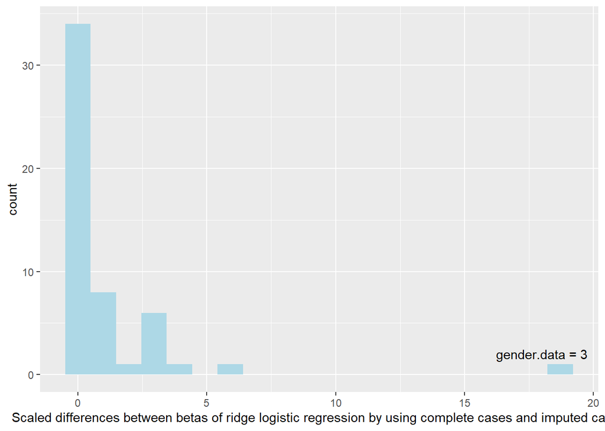

```r
library(ggplot2)
# read estimated veta of different

beta_MI_LR <- ridge.logistic.beta.cc
beta_LR <- ridge.logistic.beta.mi
coln = colnames(test)[2:53]
dat1 = as.data.frame(coln)

# diff_beta = LR - imputed LR
dat1$diff_beta = abs((as.numeric(beta_LR) - as.numeric(beta_MI_LR))/ as.numeric(beta_MI_LR))
ggplot(dat1, aes( x=diff_beta)) +
  geom_histogram(bins = 20,fill = "lightblue")+ annotate("text", x=18, y=2, label= "gender.data = 3")+labs(x ="Scaled differences between betas of ridge logistic regression by using complete cases and imputed cases" )
```

For the purpose of the main analysis, the predicted probabilities for the test set for various methods are summarized as follows:

- CC logistic regression: `logistic.cc`
- CC ridge logistic regression: `ridge.logistic.cc`
- MI logistic regression: `logistic.mi`
- MI ridge logistic regression: `ridge.logistic.mi`

For the purpose of the sensitivity analysis, the estimated regression coefficients for LR and ridge LR are summarized as:

- CC logistic regression coefficients: `logistic.beta.cc`
- CC ridge logistic regression coefficients: `ridge.logistic.beta.cc`
- MI logistic regression coefficients: `logistic.beta.mi`
- MI ridge logistic regression coefficients: `ridge.logistic.beta.mi`